# CQF Exam Three

## Machine Learning

Shota Wada  
Submission Date: 2024-10-31

## Objective

Your objective is to produce a model to predict positive moves (up trend) using machine learning models as specified in the below section. Your proposed solution should be comprehensive with the detailed feature engineering and model architecture.

- Choose one ticker of your interest from the index, equity, ETF, crypto token, or commodity.
- Predict trend only, for a short-term return (example: daily, 6 hours). Limit prediction to binomial classification: the dependent variable is best labeled [0, 1]. Avoid using [-1, 1] as class labels.
- Analysis should be comprehensive with detailed feature engineering, data pre-processing, model building, and evaluation. Devise your own approach on how to categorise extremely small near-zero returns (drop from training sample, group with positive/negative). The threshold will strongly depend on your ticker. Example: small positive returns below 0.25% can be labelled as negative. 1

Table 1. Features List

| **Feature** | **Formula** | **Description** |
| --- | --- | --- |
| *O-C, H-L* | Open - Close, High - Low | intraday price range |
| *Sign* | $\text{sign} \left[ r_t = \ln \left( \frac{P_t}{P_{t-1}} \right) \right]$ | sign of return or momentum |
| *Past Returns* | $r_{t-1}, r_{t-2}, \ldots$ | lagged returns |
| *Momentum* | $P_t - P_{t-k}$ | price change over $k$ period |
| *Moving Average* | $\text{SMA}_i = \frac{1}{n} \sum_{i=0}^{n-1} P_{t-i}$ | simple moving average |
| *Exponential MA* | $\begin{aligned} &\text{EMA}_i = \text{EMA}_{t-1} + \alpha [P_t - \text{EMA}_{t-1}] \end{aligned}$ | recursive, $\alpha = \frac{2}{(N_{obs} + 1)}$ |

Number of features to include is a design choice. There is no one recommended set of features for all assets. Length of dataset is another design choice. If predicting short-term return sign (for daily move), then training and testing over up to 5-year period should be sufficient. Making sense of instructions below is part of the task: the tutor will not assist in designing your computational implementation.

## 1. What is the cost function of Logistic Regression? Explain in Detail. [20 Marks]

### 1.1 What is Logistic Regression?

Logistic regression is a statistical method used to predict the probability of a binary outcome, meaning there are only two possible classes, such as "0" or "1,", "yes" or "no", or even "default" or "not default". Lets think about a classification problem where we try to distinguish if if email is a spam (1) or not a spam (0), one might try to use linear regression to solve this task. However, there are problem that linear regresssion will yield, such as predictions may be below 0 and above 1, which does not align with probability interpretation needed for a classification. Logistic regression addresses issues, incorporating the logistic function (laso knwon as the sigmoid function), which squeezes the output into a range between 0 and 1. Later in the section we will address this as it is crucial for obtaining meaningful class probabilities.

### 1.2 Example of Logistic Regression

Through CQF Python Labs: "Trend Predictions Using Logistic Regression" by Kannan Singaravelu, we have identified that we were able to use python code and packages to easily use Logistic Regresssion to project the momentum of index price movement. Here, I will try to explain the concept of Logistic Regression using some example rather than codes, in which we will also use to relate to answer the cost function of Logistic Regression.

Suppose we want to predict whether a student will pass or fail an exam based on the hours they study:

Data:  
Hours Studied (Feature): [2, 4, 6, 8]  
Exam Outcome (Label): [0, 0, 1, 1] where (0 = fail, 1 = pass)

We use weights (parameters) and calculate $\theta^T x$, for each example based on hours studied. This is a single value calculated as a linear combination of features and weights similar to what we do in linear regression. From here we incorporate the sigmoid function, using formula below to transform into a probability value.

$$ \sigma(\theta^T x) = \frac{1}{1 + e^{-\theta^T x}} $$

If we assume for student studying 4 hours have $\theta^T x$ = 0.8, we can use sigmoid function to get probability is roughly 0.69. This means there’s a 69% chance the student will pass (class = 1).

$$ \hat{y} = \sigma(0.8) = \frac{1}{1 + e^{-0.8}} \approx 0.69 $$

Now, if we use a default threshold of 0.5, we’d predict that this student will pass, as 0.69 > 0.5. This means that next student will pass if the (based on the hours they studied) is greater than 0.5. This probability is determined by plugging their study hours into the model's equation and applying the sigmoid function. Therefore we can say our model shows:

- High study hours → Higher probability of passing → Model prediction: "Pass"

In this example, the model outputs a probability that a student will pass based on how many hours they've studied. Therefore, when we say the model predicts a probability of 0.69, it means there is a 69% chance that the student will pass. Since probabilities range from 0 to 1, and 0.69 is a number relatively closer to 1, which indicates a higher likelihood of passing.

Of course, I have used the default threshold of 0.5, but we can change the threshold accordingly and can be useful in different situation. If we change the threshold to 0.4, we are more lenient, allowing lower probability to predict "Pass"(1) and this may be useful if we want to avoid missing students who could potentially pass (false negative: predicting "fail"(0) when they pass(1)), and vice versa.

### 1.3 What is Cost Function of Logistic Regression?

The cost function in logistic regression, also known as the "log loss" or "binary cross-entropy loss," quantifies the difference between predicted probabilities and actual class labels. It measures how well the logistic regression model's predictions align with the true labels.

Logistic regression models the probability of a binary outcome (e.g., 0 or 1) based on input features $ x $. This predicted probability of a given observation $ x $ is expressed as:

$$ P(y = 1\mid x) = \hat{y} = \sigma(\theta^T x) = \frac{1}{1 + e^{-\theta^T x}} $$

where:

- $ x $ is the input vector.
- $ \theta $ is the parameter vector.
- $ \sigma(\theta^T x) $ is the sigmoid function.

### 1.4 Deriving Cost Function of Logistic Regression

Logistic regression aims to find the best parameters $ \sigma $ that maximize the likelihood of observing the true labels given the input features. The cost function provides a way to evaluate the performance of a particular set of parameters by comparing predicted probabilities with actual labels. Therefore, the objective in logistic regression is to maximize the likelihood of the observed data, or equivalently, to minimize the "negative log-likelihood." Given a dataset of $ m $ examples, the likelihood of observing the true labels $ y $ for all instances is:

$$ L(\theta) = \prod_{i=1}^m P(y^{(i)} \mid x^{(i)}; \theta) $$

Since Taking the natural logarithm gives us the log-likelihood, and maximizing the log-likelihood is equivalent to minimizing the negative log-likelihood we can set the formula as:

$$ \log L(\theta) = \sum_{i=1}^m \log P(y^{(i)} \mid x^{(i)}; \theta) $$

which can be expressed by substitution of sigmoid function:

where:

- $ y^{(i)} $ actual example label i.
- $ \hat{y} = \sigma(\theta^T x) $ is the predicted probability of example at i.

Therefore we can use the negative log-likelihood to express the loss function, which we need to minimize in this case as our goal:

$$ L(\hat{y}, y) = - \log P(y \mid x) = - \left[ y \log (\hat{y}) + (1 - y) \log (1 - \hat{y}) \right] $$

Finally, deriving the negative log likelihood gives will give us the loss function. This is the difference between our predicted probability and the actual target value. As we have used log, this has made it easier to computationally calculate the cost of our function. In this case, the average of the loss over the training examples are our cost function, and this cost function $ J(\theta) $ for the entire training set is the average of the loss function over all training examples represented as :

$$ J(\theta) = -\frac{1}{m} \sum_{i=1}^m \left[ y^{(i)} \log (\hat{y}^{(i)}) + (1 - y^{(i)}) \log (1 - \hat{y}^{(i)}) \right] $$

where:

- $ m $ is the number of training examples.
- $ y^{(i)} $ is the actual label
- $ \hat{y}^{(i)} $ is predicted probability.

This cost function is convex, which means it has a single global minimum. Therefore, optimization algorithms like gradient descent can reliably find the optimal parameters. As stated earlier, we part of the goal of using logistic regression is to find the parameter $ \theta $ so that we can minimize our cost function $ J(\theta) $. We compute the gradient (gradient descent) with respect to each parameter $ J(\theta) $ and update the parameters iteratively:

$$ \theta := \theta - \alpha \nabla_\theta J(\theta) $$

where:

- $ \alpha $ is the learning rate.
- $ \nabla_\theta J(\theta) $ is the gradient of the cost function.

### 1.5 Applying Cost Function of Logistic Regression to Example

Based on the example above, we have a model predicting the probability that a student will pass or fail an exam based on hours studied.

Example: If he student studied for 4 hours.

- Actual outcome: Pass (1)
- Predicted probability: 0.69

using this example, the cost function in logistic regression measures how well our model's predictions match the actual outcomes. For each example, it calculates a "cost" or "penalty" based on how close or far the prediction is from the actual result:

- If the model’s predicted probability is close to the true outcome (pass or fail), the cost is low.
- If the prediction is far from the true outcome, the cost is high.

For example used, the actual label shows $ y = 1 $ (meaning the student actually passed). However, the predicted probability is $ \hat{y} = 0.69 $ (which means probability of the student passing is 69%). Since $ y = 1 $ we focus on term $ -\log(\hat{y}) $, so:

$$ Cost = -\log(0.69) \approx 0.371 $$

This means, the cost for this one example is 0.371. This cost can be considered relatively low, which means our model's prediction of 0.69 (69% probability of student passing) is fairly close to actual outcome of student passing (as we used actual label $ y=1$). If in case we had model predicting a 0.9 (90% probability of passing), the cost would be even lower, and conversely, if model predicted value off like 0.3, the cost would be much higher, penalizing the model more for being incorrect.

### 1.6 Summary

Our cost function also known as the "log loss" or "binary cross-entropy loss," are defined as the difference between the probabilities which are predicted and our actual labels. Since we know that the cost function is convex, we would be able to identify the global minimum that exist. This global minimum would represent the best parameter values for our model. Therefore, our goal is to minimize our cost function to make the predicted probability as close as the actual labels, and make the trained logistic regresssion model to be as accurate as possible to get a good prediction.

## 2. What are voting classifiers in ensemble learning? [10 Marks]

### 2.1 What is Esemble Learning?

Ensemble learning is a method in machine learning technique where multiple models (also called "weak models", "base models" or "learners") are combined to solve a problem more effectively than any single model could alone. Instead of relying on one model to make predictions, ensemble methods bring together a one or more (group) of models, aiming to capitalize on their diverse strengths to enhance accuracy and stability. This method therefore help our predictions by lowering issues such as high variance, bias and overfitting.

### 2.2 Benefits of using Ensemble Learning?

Individual models each have their own strengths and limitations. By combining them, ensemble learning can reduce errors that may occur if a single model is too sensitive to specific patterns or noise in the data. When used properly, ensemble models are typically more resilient and less prone to overfitting, especially on more complex tasks.

### 2.3 Types of Ensemble Techniques

Bagging (Bootstrap Aggregating):  
This method involves training multiple models (often using the same algorithm) on different random samples from the data. One example this is used are in a random forest, where many decision trees are trained on slightly different samples, and their outputs are combined to make the final prediction. The main goal of doing this is to reduce the overall variance when predicting from the data.

Boosting:  
In boosting, models are trained sequentially, with each model aiming to correct the mistakes of the previous one. This process helps the ensemble learn from past errors, refining predictions over time. Popular boosting methods include AdaBoost and Gradient Boosting. The main goal of this model is to reduce our model bias, trying to correct the error of previous trained model.

Stacking:  
This approach involves training several models (often of different types) and then using another model, known as the "meta-learner," to learn from the outputs of these base models. Stacking lets you use each model’s strengths for different aspects of the prediction task.

Voting:  
A straightforward approach that aggregates predictions from various models based on majority or probability voting. As we aim to provide further detail about the voting esnsemble techniques, we will further dive into the voting classifies with example.

### 2.4 What are Voting Classifiers?

So, what is voting classifier? A voting classifier is a type of ensemble model that combines predictions from multiple other classifiers to reach a final decision. Each individual model makes a prediction, and the voting classifier combines these into one outcome based on the votes. Voting can be done in two main ways:

1. Hard Voting (Majority Voting) In hard voting, each model casts a single “vote” for its predicted class. The class that gets the most votes (in this case the majority) becomes the final prediction. This method is effective if we are confident that most of our models are making good predictions. For instance, if three models predict classes as A, B, and A, then the ensemble’s final prediction would be A, since it received the majority of votes.
2. Soft Voting (Weighted Voting) The second classifiers are soft voting. Instead of simple majority voting like hard voting, each model’s confidence in its prediction is considered. If the models can output probabilities for each class, soft voting takes the average of these probabilities, and the class with the highest averaged probability is chosen. This approach is generally more effective when models have varying levels of confidence, as it allows more accurate models to have a greater influence on the final prediction.

### 2.5 Applying Voting Classifiers in Prediction Example

Now, lets use previous example of student passing exam. previously we used logistic regression to predict if student will likely pass or fail. Suppose we are building a model to predict if student exam success (whether a student will pass exam (1) or fail exam (0)). Lets assume we have below data points of several student including:

- Study Hours: The number of hours the student studied.
- Attendance: The percentage of classes attended.
- Past Performance: Grades in previous exams.

The target variable is Pass (1 if the student passes, 0 if they fail). With the above data from several students, we can use few models to make predictions. Here we use three different models:

- Logistic Regression: Often good for binary classification problems. (example: maybe for to pick up linear relationships between study hours and passing probability.)
- Decision Tree: Captures non-linear relationships. (example: maybe to capture specific thresholds, such as very low attendance leading to failing predictions.)
- K-Nearest Neighbors (KNN): Useful for identifying patterns based on similarity. (example: maybe used to compare the new student with similar students, providing predictions based on nearby data points.)

As long as prediction is to judge if next student will Pass (1) or Fail(0), we can use different model as example. Once model is set, each model is trained separately on the student data. After training, each model is able to predict whether a new student is likely to pass or fail the exam.

Let’s say we have a new student with:

- Study Hours: 15
- Attendance: 80%
- Past Performance: B grade in previous exams

and when we apply to the prediction for each model, lets assume it outputs prediction as per following table:

Table 2. Prediction Results

| Model | Prediction (Pass) |
| --- | --- |
| Logistic Regression | 1 (Pass) |
| Decision Tree | 0 (Fail) |
| K-Nearest Neighbors (KNN) | 1 (Pass) |

1. Applying above table to Hard Voting (Majority Vote) Using hard voting, each model “votes” on its prediction. The final prediction is the one with the majority of votes.
- Logistic Regression votes = 1 (Pass)
- Decision Tree votes = 0 (Fail)
- KNN votes = 1 (Pass)

Since the he majority vote is Pass (2 out of 3 models predict Pass), so the ensemble prediction is that the new student will Pass the exam. In this case we aggregated multiple model to predict a that we should use prediction = 1 (Pass).

1. Applying above table to Soft Voting (Weighted Voting) Soft voting considers the probability each model assigns to each class. Suppose each model provides the following probabilities:

Table 3. Probaility of Pass and Fail for each Model

| Model | Probability of Pass (1) | Probaility of Fail (0) |
| --- | --- | --- |
| Logistic Regression | 0.75 | 0.25 |
| Decision Tree | 0.4 | 0.6 |
| K-Nearest Neighbors (KNN) | 0.65 | 0.35 |

To get the final prediction, we calculate the average probability for each class:

Average Probability of Pass (1) = $Avg(0.75, 0.4, 0.65)$ = 0.6 Average Probability of Fail (0) = $avg(0.25, 0.6, 0.35)$ = 0.4

For soft voting, based on the average probability of pass and fail, since the average probability for Pass is higher (0.60 vs. 0.40), the soft voting classififier ensemble predicts that the student will Pass (1).

### 2.6 Summary

As per stated in the definition, the voting classifies is part of ensembled learning, which allows us to aggregate predictions from various models. For example purposes, we have used small dataset and simple example, but we can conduct this analysis using following packages from "Scikit-learn".

```python
from sklearn.ensemble import VotingClassifier

#example of using VotingClassifier
voting_clf = VotingClassifier(
    estimators=[('lr', log_clf), ('dt', tree_clf), ('knn', knn_clf)],
    voting='soft'  #here we can use 'hard' for hard voting
)
```

In a real-world scenario with a larger and more varied dataset, by combining multiple model predictions through voting, the final model becomes more robust and balanced, capturing a wider range of patterns that may influence a student’s likelihood of passing.

## 3. Follow the 7-steps to model building for your selected ticker [70 Marks]

- produce a model to predict positive moves (up trend) using Support Vector Machine (SVM) model.
- tune hyperparameters for the estimator and present the best model.
- investigate the prediction quality using area under ROC curve, confusion matrix and classification report.

Note: Choice of kernels and number of hyperparameters to be optimized for the best model are design choices.

Table 4. 7-Step to Model Building

| Steps | Workflow | Remarks |
| --- | --- | --- |
| Step 1 | Understand / Ideation | Predict next trading day index price from the given dataset |
| Step 2 | Data Collection | Load the dataset from open source API: 'Yahoo Finance' |
| Step 3 | Exploratory Data Analysis | Study summary statistics |
| Step 4 | Cleaning Dataset | Imputation: Ensure no null values are present |
| Step 5 | Transformation | Perform feature scaling based on EDA |
| Step 6 | Modeling | Building and training SVM |
| Step 7 | Validation | Validating the model performance |

Table from Python Lab course : "Trend prediction using Logistic Regression" by Kannan Singaravelu

### 3.1 Ideation: Produce a model to predict positive moves (up trend) using Support Vector Machine (SVM) model. (Step 1)

In this section, I will be using python to produce a model to predict positive moves (up trend) using Support Vector Machiene (SVM) model. As per introduction in assignment paper, short-term asset return is a challenging quantity to predict. Efficient markets produce near-Normal daily returns with no significant correlation between $ r_t $, $ r_(t−1) $. This assignment is a limited exercise in supervised learning, to explore multiple features we can use a set of features from Table 1.

To begin, I am will be installing necessary packages below, to complete 7-Steps to model building.

```python
#base libraries
import pandas as pd
import numpy as np

#data source
import yfinance as yf

#quantmod
from quantmod.datasets import fetch_historical_data
from quantmod.timeseries import *
from quantmod.indicators import BBands

#analysis
import quantstats_lumi as qs

#plotting
import matplotlib.pyplot as plt
from pylab import plt
import seaborn as sns
#import shap

#model and processing
from sklearn.model_selection import (
                                    train_test_split,
                                    GridSearchCV,
                                    TimeSeriesSplit
                                    )
from sklearn.pipeline import Pipeline
from sklearn.preprocessing import StandardScaler,MinMaxScaler
from sklearn.feature_selection import SelectKBest,f_classif,RFECV,chi2,SelectFromModel
#from statsmodels.stats.outliers_influence import variance_inflation_factor

#classifier
from sklearn.linear_model import Lasso, Ridge, ElasticNet, LogisticRegression, LinearRegression

#metrics
from sklearn.metrics import (
                            accuracy_score,
                            f1_score,
                            log_loss,
                            RocCurveDisplay,
                            ConfusionMatrixDisplay,
                            classification_report,
                            roc_curve,
                            precision_recall_curve,
                            mean_squared_error,
                            r2_score,
                            auc,
                            roc_auc_score,
                            confusion_matrix
                            )

#svc
from sklearn.svm import SVC

#warnings
import warnings
warnings.filterwarnings('ignore')
warnings.simplefilter(action='ignore', category=FutureWarning)
```

```python
#code to install extra packages below (for my uv env)
    #!uv pip install joblib
    #!uv pip install shap --
    #!uv pip install scikit-learn
    #!uv pip install statsmodel --
```

### 3.2 Data Collection: Load Dataset to conduct analysis. (Step 2)

For this assignment, I will be using equity ticker 'AMERICAN EXPRESS COMPANY' and will be pulling data from Yahoo!finance as source. Once pulled, I will be saving the data into a csv, and transform the multi-index to a single-index csv file. The date specified will be from early 2023 to check short term trend.

```python
#Load Data
df = yf.download("AXP", start="2023-01-01", end="2024-10-01", period = '1d')
```

```
[*********************100%***********************]  1 of 1 completed
```

```python
df.head()
```

| Price Ticker Date | Adj Close AXP | Close AXP | High AXP | Low AXP | Open AXP | Volume AXP |
| --- | --- | --- | --- | --- | --- | --- |
| 2023-01-03 00:00:00+00:00 | 143.260437 | 147.119995 | 150.449997 | 145.729996 | 149.539993 | 2762200 |
| 2023-01-04 00:00:00+00:00 | 146.590714 | 150.539993 | 151.960007 | 148.559998 | 148.559998 | 2620400 |
| 2023-01-05 00:00:00+00:00 | 143.082764 | 146.429993 | 148.720001 | 146.020004 | 147.160004 | 2505700 |
| 2023-01-06 00:00:00+00:00 | 146.737274 | 150.169998 | 150.429993 | 145.479996 | 147.740005 | 3077400 |
| 2023-01-09 00:00:00+00:00 | 146.962021 | 150.399994 | 152.449997 | 150.100006 | 151.350006 | 3219400 |

```python
#save data as there are multi-index in file
#df.to_csv('axp_data.csv')

#modify the multi-index to single-index to make things simple for later analysis
df = pd.read_csv('axp_data.csv', index_col=0)
df
```

| Date | Adj Close | Close | High | Low | Open | Volume |
| --- | --- | --- | --- | --- | --- | --- |
| 2023-01-03 00:00:00+00:00 | 143.260437 | 147.119995 | 150.449997 | 145.729996 | 149.539993 | 2762200 |
| 2023-01-04 00:00:00+00:00 | 146.590714 | 150.539993 | 151.960007 | 148.559998 | 148.559998 | 2620400 |
| 2023-01-05 00:00:00+00:00 | 143.082764 | 146.429993 | 148.720001 | 146.020004 | 147.160004 | 2505700 |
| 2023-01-06 00:00:00+00:00 | 146.737274 | 150.169998 | 150.429993 | 145.479996 | 147.740005 | 3077400 |
| 2023-01-09 00:00:00+00:00 | 146.962021 | 150.399994 | 152.449997 | 150.100006 | 151.350006 | 3219400 |
| ... | ... | ... | ... | ... | ... | ... |
| 2024-09-24 00:00:00+00:00 | 265.516205 | 266.209991 | 268.500000 | 263.029999 | 267.769989 | 2340300 |
| 2024-09-25 00:00:00+00:00 | 265.476318 | 266.170013 | 268.720001 | 265.549988 | 267.089996 | 2116300 |
| 2024-09-26 00:00:00+00:00 | 267.451141 | 268.149994 | 268.989990 | 266.339996 | 268.290009 | 1430600 |
| 2024-09-27 00:00:00+00:00 | 270.353546 | 271.059998 | 272.679993 | 267.420013 | 268.000000 | 2231900 |
| 2024-09-30 00:00:00+00:00 | 270.493195 | 271.200012 | 271.480011 | 267.290009 | 270.100006 | 2113100 |

438 rows × 6 columns

```python
#verify the index
df.info()
```

```
<class 'pandas.core.frame.DataFrame'>
Index: 438 entries, 2023-01-03 00:00:00+00:00 to 2024-09-30 00:00:00+00:00
Data columns (total 6 columns):
 #   Column     Non-Null Count  Dtype
---  ------     --------------  -----
 0   Adj Close  438 non-null    float64
 1   Close      438 non-null    float64
 2   High       438 non-null    float64
 3   Low        438 non-null    float64
 4   Open       438 non-null    float64
 5   Volume     438 non-null    int64
dtypes: float64(5), int64(1)
memory usage: 24.0+ KB
```

```python
#confirm if the index is datetime column
#convert the index to datetime
df.index = pd.to_datetime(df.index)
df.index
```

```
DatetimeIndex(['2023-01-03 00:00:00+00:00', '2023-01-04 00:00:00+00:00',
               '2023-01-05 00:00:00+00:00', '2023-01-06 00:00:00+00:00',
               '2023-01-09 00:00:00+00:00', '2023-01-10 00:00:00+00:00',
               '2023-01-11 00:00:00+00:00', '2023-01-12 00:00:00+00:00',
               '2023-01-13 00:00:00+00:00', '2023-01-17 00:00:00+00:00',
               ...
               '2024-09-17 00:00:00+00:00', '2024-09-18 00:00:00+00:00',
               '2024-09-19 00:00:00+00:00', '2024-09-20 00:00:00+00:00',
               '2024-09-23 00:00:00+00:00', '2024-09-24 00:00:00+00:00',
               '2024-09-25 00:00:00+00:00', '2024-09-26 00:00:00+00:00',
               '2024-09-27 00:00:00+00:00', '2024-09-30 00:00:00+00:00'],
              dtype='datetime64[ns, UTC]', name='Date', length=438, freq=None)
```

```python
#check date and column: (rows of date, column)
df.shape
```

```
(438, 6)
```

```python
#doublecheck for missing values
df.isnull().sum()
```

```
Adj Close    0
Close        0
High         0
Low          0
Open         0
Volume       0
dtype: int64
```

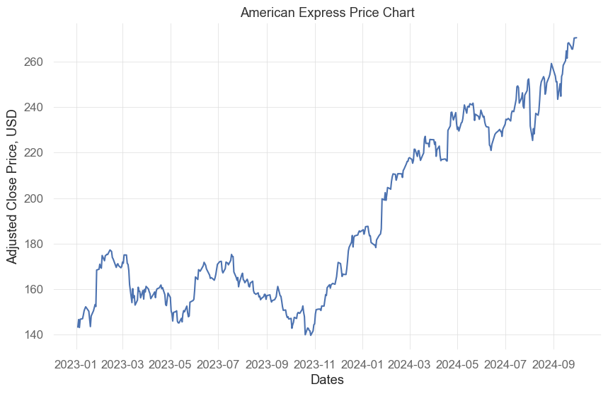

```python
#plotting data to check historicla price
plt.plot(df['Adj Close'])
plt.title('American Express Price Chart')
plt.ylabel('Adjusted Close Price, USD')
plt.xlabel('Dates');
```

### 3.3 Exploratory Data Analysis: Generating features and Lables and Analysis on Summary Statistics (Step 3)

#### 3.3.1 Feature Engineering

```python
# generating features and labels
def generate_xy(frame):
    #calculate percentage return
    frame['Returns'] = frame['Adj Close'].pct_change()

    #calculate O-C and H-L
    frame['O-C'] = frame.Open - frame.Close
    frame['H-L'] = frame.High - frame.Low

    #calculate sign in -1 or 1 for the change in natural log prices
    #for base 10 log we use np.log10
    frame['Sign'] = np.sign(np.log(frame['Adj Close']).diff())

    #create features for past returns, momentum, and moving averages
    n = [i for i in range(1, 11)]
    for i in n:
        #past Return
        frame['PastReturn' + str(i)] = frame['Returns'].shift(i)

        #momentum
        frame['Momentum' + str(i)] = frame['Adj Close'].diff(i)

        #moving Average
        frame['SMA' + str(i)] = frame['Adj Close'].rolling(window=i).mean()

    #calculate Exponential Moving Average (EMA)
    alpha = 2 / (len(frame) + 1)
    frame['EMA'] = frame['Adj Close'].ewm(span=len(frame), adjust=False).mean()

    #create labels based on future price movement
    #as per assignment request we have set dependent variable = label as [0, 1]
    frame['Label'] = np.where(frame['Adj Close'].shift(-1) > 0.9975 * frame['Adj Close'], 1, 0)

    #drop rows with NaN values
    frame = frame.dropna()

    return frame
```

$$ y_t = \begin{cases} 1, & \text{if } p_{t+1} > 0.9975 \times p_t \\ 0, & \text{otherwise} \end{cases} $$

```python
#creating dataset without unnecessary features and dependent variable 'Label' to show
data = generate_xy(df)
X = data.drop(columns=['Open', 'High', 'Low', 'Close', 'Adj Close', 'Volume', 'Returns', 'Label'])
X
```

| Date | O-C | H-L | Sign | PastReturn1 | Momentum1 | SMA1 | PastReturn2 | Momentum2 | SMA2 | PastReturn3 | ... | PastReturn8 | Momentum8 | SMA8 | PastReturn9 | Momentum9 | SMA9 | PastReturn10 | Momentum10 | SMA10 | EMA |
| --- | --- | --- | --- | --- | --- | --- | --- | --- | --- | --- | --- | --- | --- | --- | --- | --- | --- | --- | --- | --- | --- |
| 2023-01-19 00:00:00+00:00 | -0.240005 | 3.800003 | -1.0 | -0.021659 | -3.488403 | 143.493179 | -0.012904 | -6.742279 | 145.237381 | 0.005422 | ... | 0.025541 | -3.244095 | 148.772186 | -0.023930 | 0.410416 | 148.546085 | 0.023246 | -3.097534 | 147.999753 | 143.486808 |
| 2023-01-20 00:00:00+00:00 | -3.639999 | 4.059998 | 1.0 | -0.023734 | 4.641434 | 148.134613 | -0.021659 | 1.153030 | 145.813896 | -0.012904 | ... | 0.001532 | 1.172592 | 148.918760 | 0.025541 | 1.397339 | 148.701345 | -0.023930 | 5.051849 | 148.504938 | 143.507982 |
| 2023-01-23 00:00:00+00:00 | -2.000000 | 3.509995 | 1.0 | 0.032346 | 2.345139 | 150.479752 | -0.023734 | 6.986572 | 149.307182 | -0.021659 | ... | 0.010638 | 1.954300 | 149.163048 | 0.001532 | 3.517731 | 149.092204 | 0.025541 | 3.742477 | 148.879185 | 143.539744 |
| 2023-01-24 00:00:00+00:00 | -2.410004 | 4.009995 | 1.0 | 0.015831 | 1.299606 | 151.779358 | 0.032346 | 3.644745 | 151.129555 | -0.023734 | ... | 0.012632 | 1.377777 | 149.335270 | 0.010638 | 3.253906 | 149.453749 | 0.001532 | 4.817337 | 149.360919 | 143.577282 |
| 2023-01-25 00:00:00+00:00 | -3.279999 | 3.690002 | 1.0 | 0.008636 | 1.407074 | 153.186432 | 0.015831 | 2.706680 | 152.482895 | 0.032346 | ... | 0.006497 | 1.807724 | 149.561235 | 0.012632 | 2.784851 | 149.763177 | 0.010638 | 4.660980 | 149.827017 | 143.621060 |
| ... | ... | ... | ... | ... | ... | ... | ... | ... | ... | ... | ... | ... | ... | ... | ... | ... | ... | ... | ... | ... | ... |
| 2024-09-24 00:00:00+00:00 | 1.559998 | 5.470001 | -1.0 | -0.006283 | -1.087128 | 265.516205 | 0.000893 | -2.772736 | 266.059769 | 0.025059 | ... | 0.003816 | 11.031189 | 264.174702 | 0.035694 | 11.998657 | 263.098070 | -0.021919 | 20.735825 | 262.140018 | 198.614300 |
| 2024-09-25 00:00:00+00:00 | 0.919983 | 3.170013 | -1.0 | -0.004078 | -0.039886 | 265.476318 | -0.006283 | -1.127014 | 265.496262 | 0.000893 | ... | 0.015089 | 7.151337 | 265.068619 | 0.003816 | 10.991302 | 264.319326 | 0.035694 | 11.958771 | 263.335895 | 198.918910 |
| 2024-09-26 00:00:00+00:00 | 0.140015 | 2.649994 | 1.0 | -0.000150 | 1.974823 | 267.451141 | -0.004078 | 1.934937 | 266.463730 | -0.006283 | ... | 0.008070 | 7.041595 | 265.948818 | 0.015089 | 9.126160 | 265.333344 | 0.003816 | 12.966125 | 264.632507 | 199.231130 |
| 2024-09-27 00:00:00+00:00 | -3.059998 | 5.259979 | 1.0 | 0.007439 | 2.902405 | 270.353546 | -0.000150 | 4.877228 | 268.902344 | -0.004078 | ... | 0.016508 | 5.645233 | 266.654472 | 0.008070 | 9.944000 | 266.438232 | 0.015089 | 12.028564 | 265.835364 | 199.555150 |
| 2024-09-30 00:00:00+00:00 | -1.100006 | 4.190002 | 1.0 | 0.010852 | 0.139648 | 270.493195 | 0.007439 | 3.042053 | 270.423370 | -0.000150 | ... | -0.012133 | 8.996490 | 267.779034 | 0.016508 | 5.784882 | 267.080997 | 0.008070 | 10.083649 | 266.843729 | 199.878330 |

427 rows × 34 columns

In above table, we have removed 'Open', 'High', 'Low', 'Close', 'Adj Close', 'Volume', 'Returns', as our 'Label' is created based on 'Adj Close'. Since we are pulling movement of price, this usually has positive correlation with price fields specified to the above.

Now, we can continue with this data, but we see there are 34 features still available. What we can do is reduce this value even further by conducting feature selection. in this assignment, I will also aply correlation based feature selection.

Next, will be reducing the input variables using correlation measures to filter out to address multicollinearity amongs these features. From 7 features in Table 1 referenced above, I have expanded the feature to 34 features. Since this may be too large, I would reduce this number by checking correlation between features, and drop the features that is closely correlated between each.

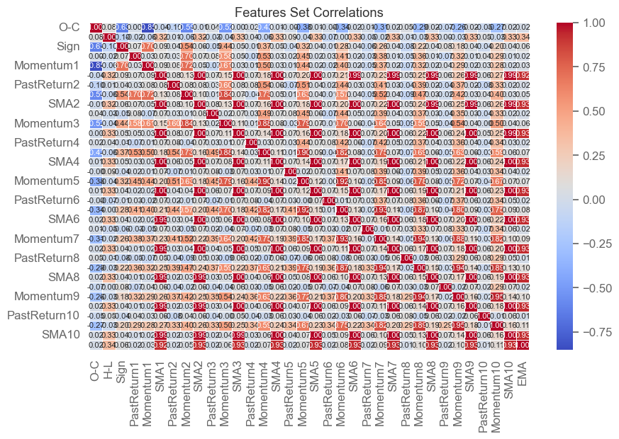

```python
#check multicollinearity, by checking the correltation
sns.heatmap(X.corr(),
    annot=True,
    annot_kws={"size": 8},
    fmt=".2f",
    linewidth=.5,
    cmap="coolwarm",
    cbar=True); #cmap="crest", virids, magma
plt.title('Features Set Correlations');
```

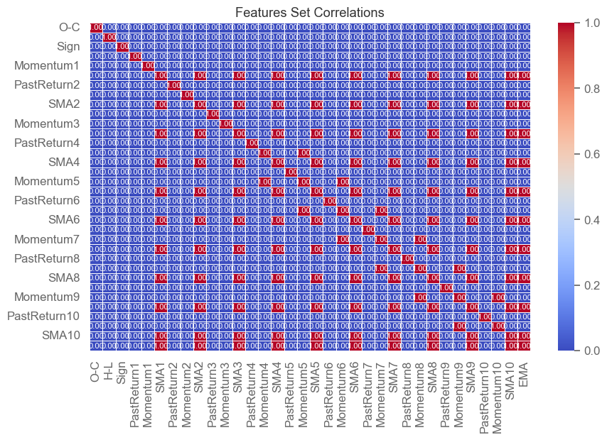

```python
#check multicollinearity with correlation >9, by checking the correltation
sns.heatmap(X.corr() > 0.9,
    annot=True,
    annot_kws={"size": 8},
    fmt=".2f",
    linewidth=.5,
    cmap="coolwarm",
    cbar=True); #cmap="crest", virids, magma
plt.title('Features Set Correlations');
```

```python
#create definition to remove the first feature that is correlated with any other feature
def correlated_features(X, threshold=0.9):
    col_corr = set()
    corr_matrix = X.corr()
    for i in range(len(corr_matrix.columns)):
     for j in range(i):
        if abs(corr_matrix.iloc[i, j]) > threshold:
            colname = corr_matrix.columns[i]
            col_corr.add(colname)
    return col_corr
```

```python
#look at the features with high correlation
correlated_features(X)
```

```
{'EMA',
 'Momentum10',
 'Momentum5',
 'Momentum6',
 'Momentum7',
 'Momentum8',
 'Momentum9',
 'SMA10',
 'SMA2',
 'SMA3',
 'SMA4',
 'SMA5',
 'SMA6',
 'SMA7',
 'SMA8',
 'SMA9'}
```

```python
#total correlated features
drop_correlated_features = correlated_features(X)

#drop the highly correlated features and 'Signs' as this shows 1 and -1
X = X.drop(drop_correlated_features, axis=1)
X = X.drop(columns=['Sign'])

# record feature names
feature_names = X.columns

#recall that y = data['label'] as per previously defined
```

```python
#show the X data with dropped correlation
#we also want to take off original features such as Adj Close, Volume, Returns, and Label as per previously stated
X
```

| Date | O-C | H-L | PastReturn1 | Momentum1 | SMA1 | PastReturn2 | Momentum2 | PastReturn3 | Momentum3 | PastReturn4 | Momentum4 | PastReturn5 | PastReturn6 | PastReturn7 | PastReturn8 | PastReturn9 | PastReturn10 |
| --- | --- | --- | --- | --- | --- | --- | --- | --- | --- | --- | --- | --- | --- | --- | --- | --- | --- |
| 2023-01-19 00:00:00+00:00 | -0.240005 | 3.800003 | -0.021659 | -3.488403 | 143.493179 | -0.012904 | -6.742279 | 0.005422 | -8.706329 | 0.006497 | -7.885529 | 0.012632 | 0.010638 | 0.001532 | 0.025541 | -0.023930 | 0.023246 |
| 2023-01-20 00:00:00+00:00 | -3.639999 | 4.059998 | -0.023734 | 4.641434 | 148.134613 | -0.021659 | 1.153030 | -0.012904 | -2.100845 | 0.005422 | -4.064896 | 0.006497 | 0.012632 | 0.010638 | 0.001532 | 0.025541 | -0.023930 |
| 2023-01-23 00:00:00+00:00 | -2.000000 | 3.509995 | 0.032346 | 2.345139 | 150.479752 | -0.023734 | 6.986572 | -0.021659 | 3.498169 | -0.012904 | 0.244293 | 0.005422 | 0.006497 | 0.012632 | 0.010638 | 0.001532 | 0.025541 |
| 2023-01-24 00:00:00+00:00 | -2.410004 | 4.009995 | 0.015831 | 1.299606 | 151.779358 | 0.032346 | 3.644745 | -0.023734 | 8.286179 | -0.021659 | 4.797775 | -0.012904 | 0.005422 | 0.006497 | 0.012632 | 0.010638 | 0.001532 |
| 2023-01-25 00:00:00+00:00 | -3.279999 | 3.690002 | 0.008636 | 1.407074 | 153.186432 | 0.015831 | 2.706680 | 0.032346 | 5.051819 | -0.023734 | 9.693253 | -0.021659 | -0.012904 | 0.005422 | 0.006497 | 0.012632 | 0.010638 |
| ... | ... | ... | ... | ... | ... | ... | ... | ... | ... | ... | ... | ... | ... | ... | ... | ... | ... |
| 2024-09-24 00:00:00+00:00 | 1.559998 | 5.470001 | -0.006283 | -1.087128 | 265.516205 | 0.000893 | -2.772736 | 0.025059 | -2.533386 | -0.012133 | 4.019501 | 0.016508 | 0.008070 | 0.015089 | 0.003816 | 0.035694 | -0.021919 |
| 2024-09-25 00:00:00+00:00 | 0.919983 | 3.170013 | -0.004078 | -0.039886 | 265.476318 | -0.006283 | -1.127014 | 0.000893 | -2.812622 | 0.025059 | -2.573273 | -0.012133 | 0.016508 | 0.008070 | 0.015089 | 0.003816 | 0.035694 |
| 2024-09-26 00:00:00+00:00 | 0.140015 | 2.649994 | -0.000150 | 1.974823 | 267.451141 | -0.004078 | 1.934937 | -0.006283 | 0.847809 | 0.000893 | -0.837799 | 0.025059 | -0.012133 | 0.016508 | 0.008070 | 0.015089 | 0.003816 |
| 2024-09-27 00:00:00+00:00 | -3.059998 | 5.259979 | 0.007439 | 2.902405 | 270.353546 | -0.000150 | 4.877228 | -0.004078 | 4.837341 | -0.006283 | 3.750214 | 0.000893 | 0.025059 | -0.012133 | 0.016508 | 0.008070 | 0.015089 |
| 2024-09-30 00:00:00+00:00 | -1.100006 | 4.190002 | 0.010852 | 0.139648 | 270.493195 | 0.007439 | 3.042053 | -0.000150 | 5.016876 | -0.004078 | 4.976990 | -0.006283 | 0.000893 | 0.025059 | -0.012133 | 0.016508 | 0.008070 |

427 rows × 17 columns

```python
#what we are left should be following column features
feature_names
```

```
Index(['O-C', 'H-L', 'PastReturn1', 'Momentum1', 'SMA1', 'PastReturn2',
       'Momentum2', 'PastReturn3', 'Momentum3', 'PastReturn4', 'Momentum4',
       'PastReturn5', 'PastReturn6', 'PastReturn7', 'PastReturn8',
       'PastReturn9', 'PastReturn10'],
      dtype='object')
```

```python
X.info()
```

```
<class 'pandas.core.frame.DataFrame'>
DatetimeIndex: 427 entries, 2023-01-19 00:00:00+00:00 to 2024-09-30 00:00:00+00:00
Data columns (total 17 columns):
 #   Column        Non-Null Count  Dtype
---  ------        --------------  -----
 0   O-C           427 non-null    float64
 1   H-L           427 non-null    float64
 2   PastReturn1   427 non-null    float64
 3   Momentum1     427 non-null    float64
 4   SMA1          427 non-null    float64
 5   PastReturn2   427 non-null    float64
 6   Momentum2     427 non-null    float64
 7   PastReturn3   427 non-null    float64
 8   Momentum3     427 non-null    float64
 9   PastReturn4   427 non-null    float64
 10  Momentum4     427 non-null    float64
 11  PastReturn5   427 non-null    float64
 12  PastReturn6   427 non-null    float64
 13  PastReturn7   427 non-null    float64
 14  PastReturn8   427 non-null    float64
 15  PastReturn9   427 non-null    float64
 16  PastReturn10  427 non-null    float64
dtypes: float64(17)
memory usage: 60.0 KB
```

As you can see, from 5 data field we pulled as historical data set in yahoo!Finance, we have gathered 34 features. However, instead of using 34 features as it is too much, we have filtered out correlated features which resulted us to be left with 17 features to use for modeling.

### 3.4 Cleaning up Data and Check (Step 4)

```python
#show descriptive statistics
X.describe().T
```

|  | count | mean | std | min | 25% | 50% | 75% | max |
| --- | --- | --- | --- | --- | --- | --- | --- | --- |
| O-C | 427.0 | -0.221545 | 2.442530 | -12.199997 | -1.675003 | -0.259995 | 1.075005 | 12.229996 |
| H-L | 427.0 | 3.509508 | 1.839833 | 1.049988 | 2.369995 | 3.110001 | 4.150002 | 14.599991 |
| PastReturn1 | 427.0 | 0.001499 | 0.015725 | -0.065948 | -0.006677 | 0.001322 | 0.010395 | 0.105402 |
| Momentum1 | 427.0 | 0.289254 | 2.956732 | -16.357254 | -1.137520 | 0.239349 | 1.958679 | 16.054459 |
| SMA1 | 427.0 | 190.467557 | 37.252192 | 139.638000 | 158.280968 | 173.247147 | 227.134338 | 270.493195 |
| PastReturn2 | 427.0 | 0.001444 | 0.015734 | -0.065948 | -0.006694 | 0.001094 | 0.010292 | 0.105402 |
| Momentum2 | 427.0 | 0.570561 | 4.266796 | -22.700668 | -1.806183 | 0.503952 | 3.067513 | 16.396423 |
| PastReturn3 | 427.0 | 0.001439 | 0.015732 | -0.065948 | -0.006694 | 0.001094 | 0.010292 | 0.105402 |
| Momentum3 | 427.0 | 0.840472 | 5.384513 | -27.049316 | -2.265747 | 0.872406 | 3.817368 | 21.340515 |
| PastReturn4 | 427.0 | 0.001455 | 0.015734 | -0.065948 | -0.006694 | 0.001322 | 0.010292 | 0.105402 |
| Momentum4 | 427.0 | 1.107679 | 6.207089 | -26.490768 | -2.469193 | 1.112061 | 4.395485 | 21.499619 |
| PastReturn5 | 427.0 | 0.001494 | 0.015741 | -0.065948 | -0.006694 | 0.001408 | 0.010395 | 0.105402 |
| PastReturn6 | 427.0 | 0.001533 | 0.015743 | -0.065948 | -0.006694 | 0.001506 | 0.010525 | 0.105402 |
| PastReturn7 | 427.0 | 0.001535 | 0.015743 | -0.065948 | -0.006694 | 0.001532 | 0.010525 | 0.105402 |
| PastReturn8 | 427.0 | 0.001536 | 0.015744 | -0.065948 | -0.006694 | 0.001532 | 0.010525 | 0.105402 |
| PastReturn9 | 427.0 | 0.001508 | 0.015779 | -0.065948 | -0.006694 | 0.001532 | 0.010525 | 0.105402 |
| PastReturn10 | 427.0 | 0.001524 | 0.015797 | -0.065948 | -0.006694 | 0.001532 | 0.010525 | 0.105402 |

```python
#Check the y parameter: column "Label"
y = data['Label']
y
```

```
Date
2023-01-19 00:00:00+00:00    1
2023-01-20 00:00:00+00:00    1
2023-01-23 00:00:00+00:00    1
2023-01-24 00:00:00+00:00    1
2023-01-25 00:00:00+00:00    0
                            ..
2024-09-24 00:00:00+00:00    1
2024-09-25 00:00:00+00:00    1
2024-09-26 00:00:00+00:00    1
2024-09-27 00:00:00+00:00    1
2024-09-30 00:00:00+00:00    0
Name: Label, Length: 427, dtype: int64
```

```python
#renaming the 'label' to 'Y' to make things simple
y = data.Label
pd.Series(y).value_counts()
```

```
Label
1    280
0    147
Name: count, dtype: int64
```

```python
y.info()
```

```
<class 'pandas.core.series.Series'>
DatetimeIndex: 427 entries, 2023-01-19 00:00:00+00:00 to 2024-09-30 00:00:00+00:00
Series name: Label
Non-Null Count  Dtype
--------------  -----
427 non-null    int64
dtypes: int64(1)
memory usage: 6.7 KB
```

### 3.5 Transofrmation: Scaling and preparing for modeling. (Step 5)

#### 3.5.1 Split Data

Now that we have our data set, features and label, it is important for us to split the data into two segments:

- Training
- Testing

Training is used to train our model while the testing set is used to see how it would preform based on the model trained. These steps are important as this particular step ensures we do not have overfitting (happens when the training set goes well, but performs poorly on alternative new data).

```python
#assigning 80% train and 20% testing
X_train, X_test, y_train, y_test = train_test_split(X, y, test_size=0.2, shuffle = False)

#output the train and test data size
print(f'Train data size is {len(X_train)}')
print(f'Test data size is {len(X_test)}')
```

```
Train data size is 341
Test data size is 86
```

Since The feature set includes both basic price change metrics and engineered features that capture historical price movement, and momentum. The feature set was scaled for SVM compatibility using a "StandardScaler" to ensure that features contribute evenly to the model’s learning.

```python
#we also need to scale the model when transforming the data
#standardization
scaler = StandardScaler()
X_train = scaler.fit_transform(X_train)
X_test = scaler.transform(X_test)

print(f'Train  dimension is {X_train.shape}')
print(f'Test set dimension is {X_test.shape}')
```

```
Train  dimension is (341, 17)
Test set dimension is (86, 17)
```

### 3.6 Modeling: Building and Training the SVM Model. (Step 6)

#### 3.6.1 Using SVM Model

In this assignment we will use Support Vector Machine (SVM) for its strong performance in classification tasks and robustness against overfitting, especially with high-dimensional data and non-linear boundaries. Here, I have started with using the kernel model of the Radial Basis Function (rbf) kernel, which captures complex relationships within the data. Furthermore, Grid search with 5-fold cross-validation was employed to find the optimal parameters for the SVM model.

Key parameters tuned include:

- C: The regularisation parameter, which is inversely proportional to the strength of regularization. The lower the value, the stronger our regularization will be, so this will act as distinction between hard margin (larger the C) and soft margin (smaller the C) being used. This will control the trade-off between maximizing the margin and minimizing classification error.
- gamma: Controls the influence of a single training example, with a lower value implying a broader influence for each example, and vice versa. The gamma tuning will help balance model between under fitting and over fitting.

For the optimal parameters selected, I will be basing this on the highest AUC to ROC score during cross-validation, maximizing the model’s discriminatory power.

```python
#define parameter grid for C and gamma only using RBF kernel to show example of model building
param_grid = {
    'C': [0.1, 1, 10, 100, 1000],
    'gamma': ['scale', 'auto', 0.01, 0.1, 1],
    'kernel': ['rbf']
}

#initialize GridSearchCV with SVC estimator and AUC scoring
grid_search = GridSearchCV(SVC(), param_grid, cv=5, scoring='roc_auc', verbose=1, n_jobs=-1)
grid_search.fit(X_train, y_train)

#extract best model after grid search
best_model = grid_search.best_estimator_
print("Best Hyperparameters:", grid_search.best_params_)

grid_search = GridSearchCV(SVC(), param_grid, cv=5, scoring='roc_auc', verbose=1, n_jobs=-1)
grid_search.fit(X_train, y_train)
```

```
Fitting 5 folds for each of 25 candidates, totalling 125 fits
Best Hyperparameters: {'C': 100, 'gamma': 0.1, 'kernel': 'rbf'}
Fitting 5 folds for each of 25 candidates, totalling 125 fits
```

```
GridSearchCV(cv=5, estimator=SVC(), n_jobs=-1,
             param_grid={'C': [0.1, 1, 10, 100, 1000],
                         'gamma': ['scale', 'auto', 0.01, 0.1, 1],
                         'kernel': ['rbf']},
             scoring='roc_auc', verbose=1)
```

#### 3.6.2 Result Explanation

The best hyperparameters found were C=100 and gamma=0.1 with the RBF kernel. Theis result shows that the C, gamma, and kernel (although only rbf is used here), shows the combination that are most effective at balancing the model’s performance on the training set while also generalizing well to new data (based on measurement by the cross-validating and referencing scope of AUC score).

#### 3.6.3 Why use scoring of AUC (Area Under the Curve) of the ROC (Receiver Operating Characteristic) curve

The AUC has following positive benefits for us to use as scoring for this assignment:

1. Class Imbalance Sensitivity AUC is robust against class imbalance. For example, if upward movements are much rarer than downward ones, metrics like accuracy can be misleading. AUC focuses on the model's ability to correctly rank positive instances higher than negative ones, regardless of class distribution.
2. Measures Discrimination Power AUC evaluates how well the model separates positive and negative classes. In trading or financial prediction, and specifically for this assignment case, we care more about how well the model distinguishes an "up" trend from a "down/flat" trend than about predicting specific values.
3. Threshold Independence AUC evaluates model performance across all possible classification thresholds. This is particularly useful when we may not yet know the optimal threshold for our predictions. Instead of fixing on a specific threshold, AUC gives a broader view of the model's overall classification power.
4. Interpretability The AUC score is intuitive: a score of 0.5 means the model performs no better than random guessing, while a score close to 1 indicates high discriminative power. This makes it easy to compare models and tune parameters with clear interpretability.

Overall, I have used AUC as it can capture the model’s capacity to distinguish between "up" and "down/flat" trends comprehensively and consistently across different possible classification thresholds, even if the classes are imbalanced.

#### 3.6.4 Finding the best model based on more parameter

Since now we can identify best parameter of a model based on the param_grid specified, we can also expand the parameter to tackle different kernel types, C, and gamma. Below are example code to pull best parameter and estimator of the SVM model using GridSearch packages.

```python
#defining the parameter grid for different kernel types and C
#C is set to 0.1 -10 as function fails to run (taking huge time if we use 0.1-100)
param_grid = [
    {'kernel': ['linear'], 'C': [0.1, 1, 10]},
    {'kernel': ['poly'], 'degree': [2, 3, 5], 'C': [0.1, 1, 10]},
    {'kernel': ['rbf'], 'gamma': ['auto', 'scale'], 'C': [0.1, 1, 10]},
    {'kernel': ['sigmoid'], 'gamma': ['auto', 'scale'], 'C': [0.1, 1, 10]}
]

#set scv = SVC model
svc = SVC()

#set up GridSearchCV to find the best combination of parameters
grid_search = GridSearchCV(estimator=svc, param_grid=param_grid, scoring='roc_auc', cv=5, n_jobs=-1, verbose=1)
grid_search.fit(X_train, y_train)

#get the best model and parameters
best_model = grid_search.best_estimator_
best_params = grid_search.best_params_

print("Best Model:", best_model)
print("Best Parameters:", best_params)
```

```
Fitting 5 folds for each of 24 candidates, totalling 120 fits
Best Model: SVC(C=10, degree=5, kernel='poly')
Best Parameters: {'C': 10, 'degree': 5, 'kernel': 'poly'}
```

After getting the Best Model and Best Parameters as per above, we can see that Best Model for suited for the data is to predict is SVC with 'Poly', which is a polynomial kernel that enables non-linear classification by creating polynomial decision boundaries. furthermore, 'degree' here applies to polinomial kernel, which specifies the degree of the polynomial function used. Higher values mean more complex decision boundaries, but they can also increase the risk of overfitting. The combination of **SVC(C=10, degree=5, kernel='poly')** was best suited for modeling and predicting the momentum of the stock projection accordingly.

This code above provides the best-performing SVM model based on our data with the selected kernels and hyperparameters. With this best model, we can further check and evaluate this models using a confusion matrix, AUC-ROC curve, and classification report. we will use the best_model defiition, to further evaluate and validate our modeling.

### 3.7 Model Evaluation and Validation (Step 7)

#### 3.7.1 Metrics for Evaluation for our SVM Model in the assignment.

To evaluate the SVM model’s effectiveness, we used the following metrics:

- Area Under the ROC Curve (AUC): Measures the model’s ability to distinguish between upward and non-upward trends.
- Confusion Matrix: Provides insight into correct and incorrect classifications across true positives, false positives, true negatives, and false negatives.
- Classification Report: Includes precision, recall, F1-score, and accuracy for both classes, offering a comprehensive view of the model’s performance.

Using below code, I would be able to evaluate the above points

```python
y_pred = best_model.predict(X_test)
y_pred_proba = best_model.decision_function(X_test)
```

```python
#AUC score of the model.
#we can also run AUC score with all model and hyperparameters. value we see will be the best_model prediction.
auc_score = roc_auc_score(y_test, y_pred_proba)
print("AUC Score:", auc_score)
```

```
AUC Score: 0.6091954022988505
```

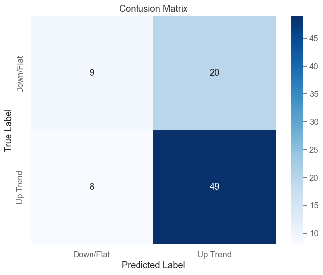

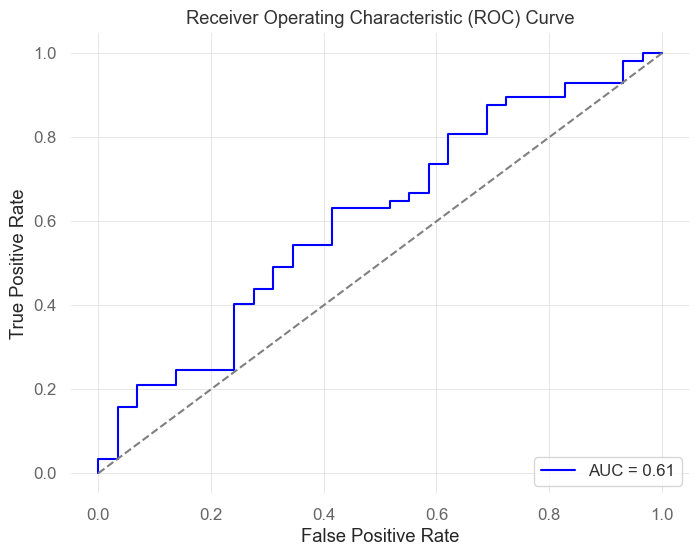

```
Classification Report:
               precision    recall  f1-score   support

           0       0.53      0.31      0.39        29
           1       0.71      0.86      0.78        57

    accuracy                           0.67        86
   macro avg       0.62      0.58      0.58        86
weighted avg       0.65      0.67      0.65        86
```

```python
#with 'best_model' being best trained SVM model, and X_test and y_test are the test set

#we can pull confusion matrix
#predict on X_test (test set)
y_pred = best_model.predict(X_test)

#gnerating the confusion matrix
conf_matrix = confusion_matrix(y_test, y_pred)

#plotting the confusion matrix
plt.figure(figsize=(8, 6))
sns.heatmap(conf_matrix, annot=True, fmt='d', cmap='Blues',
            xticklabels=['Down/Flat', 'Up Trend'],
            yticklabels=['Down/Flat', 'Up Trend'])
plt.title('Confusion Matrix')
plt.ylabel('True Label')
plt.xlabel('Predicted Label')
plt.show()

#generate AUC-ROC Curve
#get predicted probabilities for the positive class (1)
y_pred_proba = best_model.decision_function(X_test)

#calculate ROC curve and AUC score
fpr, tpr, thresholds = roc_curve(y_test, y_pred_proba)
roc_auc = auc(fpr, tpr)

#ploting the AUC curve
plt.figure(figsize=(8, 6))
plt.plot(fpr, tpr, color='blue', label=f'AUC = {roc_auc:.2f}')
plt.plot([0, 1], [0, 1], color='gray', linestyle='--')
plt.xlabel('False Positive Rate')
plt.ylabel('True Positive Rate')
plt.title('Receiver Operating Characteristic (ROC) Curve')
plt.legend(loc='lower right')
plt.show()

#get clasification report
print("Classification Report:\n", classification_report(y_test, y_pred))
```

Based on the above evaluations, have identified that model we trained produced following result:

- AUC Score:

The score of 0.61 indicates that the model has some ability to distinguish between upward and non-upward trends, though there is room for improvement. The curve stays on the true-positive side (left of the 50:50 line), suggesting it has a tendency to identify positive moves, as this number represents the probability that the model will rank a randomly chosen positive instance (upward trend) higher than a randomly chosen negative instance (non-upward trend).

Although AUC of 0.61 is higher than 0.5 (which indicates random guessing), is not close to 1.0, which would represent perfect discrimination between classes. This score indicates that the model's capacity to separate upward trends from non-upward trends is somewhat limited. What we can assume here is that the model is likely capturing instances where it might confuse an upward trend with non-upward trend and vice versa.

To enhance the model, we can further conduct optimization to improve its accuracy and reliability. Possible improvements could involve fine-tuning hyperparameters, testing different feature sets, or trying alternative model architecture for supervised learning.

- Confusion Matrix:

- Classification Report:

Based on this classification report, here’s a breakdown of the key metrics and what they indicate about the model’s performance for each class:

1. Class 0 (Non-Upward Trend):  
   Precision: 0.53 – When the model predicts a non-upward trend, it’s correct 53% of the time.  
   Recall: 0.31 – The model only identifies 31% of actual non-upward trends correctly, indicating it misses many cases.  
   F1-score: 0.39 – This score balances precision and recall, reflecting a low performance on non-upward trends, largely due to the low recall.
2. Class 1 (Upward Trend):  
   Precision: 0.71 – The model is correct 71% of the time when it predicts an upward trend.  
   Recall: 0.86 – The model captures 86% of actual upward trends, which is strong, meaning it rarely misses upward trends.  
   F1-score: 0.78 – This balanced measure indicates solid performance for predicting upward trends, given the high recall.
1. Overall Metrics:  
   Accuracy: 0.67 – The model is correct in 67% of cases overall, which shows moderate predictive performance.  
   Macro Average: Shows the average of precision, recall, and F1-score across both classes without considering class imbalance.  
   Here, both recall and F1-score are at 0.58, highlighting weaker performance overall for the minority class (non-upward trend).  
   Weighted Average: This takes class imbalance into account, giving more weight to Class 1 due to its higher support. The weighted precision, recall, and F1-score align with the overall accuracy of 0.67.

From the classification report we can summarise that this model performs well for upward trend predictions (Class 1), with high recall and a decent F1-score, indicating it effectively captures upward trends. However, this model may also struggle with non-upward trend predictions (Class 0), as seen in the lower recall and F1-score for this class. This imbalance shows that the model is definately suited for identifiying upward trend.

With all above, the SVM model demonstrates a reasonable ability to predict upward trends, showing strong recall and F1-scores for positive cases, though it struggles with accurately identifying non-upward trends. The AUC score of 0.61 and the confusion matrix's distribution highlight both strengths and areas for improvement, suggesting that further refinement of the model could enhance its predictive capabilities for both upward and non-upward trends.

## References

CQF Module 4 Lecture 2: A Introduction to Machiene Learning II - Dr. Paul Wilmott

CQF Module 4 Lecture 4: Supervised Learning I - Kannan Singaravelu

CQF Module 4 Lecture 5: Supervised Learning II - Kannan Singaravelu

CQF Module 4 Lecture 6: Decision Trees & Ensemble - Dr. Panos Parpas

CQF Python Labs - June 2024: Introduction to Machiene Learning using Scikit-learn - Kannan Singaravelu

CQF Python Labs - June 2024: Gradient Boosting for Price Prediction - Kannan Singaravelu

1.11.1 Ensembles: Gradient boosting, random forests, bagging, voting, stacking - https://scikit-learn.org/stable/modules/ensemble.html